# Ash Tree Susceptibility To Chalara Ash Dieback

Exam number Y3868110

# 1 Introduction

One of the most common native trees to the UK is the common ash tree and it plays a vital role within the country’s ecosystem by supporting many other organisms such as insects, mosses and lichens. However, the fungus *Hymenoscyphus fraxineus* which can cause Chalara ash dieback is killing many of these trees, not just in the UK but also across Europe, and is threatening the survival of those dependent organisms (Forest Research 2020). It was established that when exposed to the fungus some ash trees show less severe symptoms or are even able to remain completely unaffected by the disease compared to other trees despite being members of the same species.

By analysing the relationship between disease susceptibility and gene expression levels in the common ash tree, it could be possible to identify which genes give rise to tolerance to Chalara ash dieback and hence contribute to saving the keystone species. This can be achieved by performing differential gene expression analysis of RNA-sequencing data to determine which genes are differentially expressed between trees with different susceptibilities. It is important that this analysis is reproducible due to the large number of trees and genes that need to be analysed in order to create an accurate model for Chalara susceptibility.

In this report, sample RNA-Seq data from common ash trees (*Fraxinus excelsior*) with different levels of susceptibility to Chalara ash dieback will be used to demonstrate how this analysis can be done. R (R Core Team 2019) with **`tidyverse`** packages (Wickham 2017) was used for all analyses and the **`rmarkdown`** (Allaire et al. 2019) and **`bookdown`** (Xie 2016) packages were used for manuscript preparation.

# 2 Data tidying

The sample data used consisted of two files :

- ash_expression.txt containing expression levels of 32701 genes for 14 different ash trees
- ash_trait.txt containing whether the same trees were tolerant or susceptible to Chalara ash dieback

In both files each tree sampled was entered in the format “Ash000” so in order to make the data easier to analyse these labels were renamed to “000”. For the expression data this involved renaming the columns and reordering them into ascending order - this tidy data was saved as expression.txt. For the trait data this involved renaming the rows and reordering them into the same ascending order - this tidy data was saved as trait.txt. It is essential that the expression data column names are equal to the trait data row names for the differential expression analysis.

# 3 Differential gene expression analysis

## 3.1 Methods

The tidied expression data was converted into a matrix and the tidied trait data was read into the correct format. A DESeq2 dataset was then created, low counts were removed and “susceptible” trees were chosen as the control. Differential expression analysis was performed using DESeq2 which uses a Wald test to determine if gene expression levels in tolerant trees are the same as those in susceptible trees. If the p-value for a gene is small, the null hypothesis must be rejected meaning there is evidence that the gene is differentially expressed between the tolerant and susceptible trees. In this sample data of 32701 genes, just 12 have a p-value < 0.01 so are significantly differentially expressed.

To help identify the most significant genes the Log2 fold-change values need to be “shrunk” to reduce noise, using the function **`lfcShrink()`** which requires the package ‘apeglm’ from BiocManager (Zhu, Ibrahim, and Love 2018) (Note: this does not change the total number of genes previously identified as being significantly differentially expressed). The output of this was then tidied by ordering the genes by size of their p-value and saved as deseq2_lfc_results.txt.

## 3.2 Result visualisation

The DESeq2 results can be plotted as mean normalised counts against log fold-change of the mean expression levels of genes between the groups of trees. However, a more useful presentation of the results is examining the read counts across the tolerant and susceptible trees for genes of interest. For example, the most significantly differentially expressed gene can be selected using the following code :

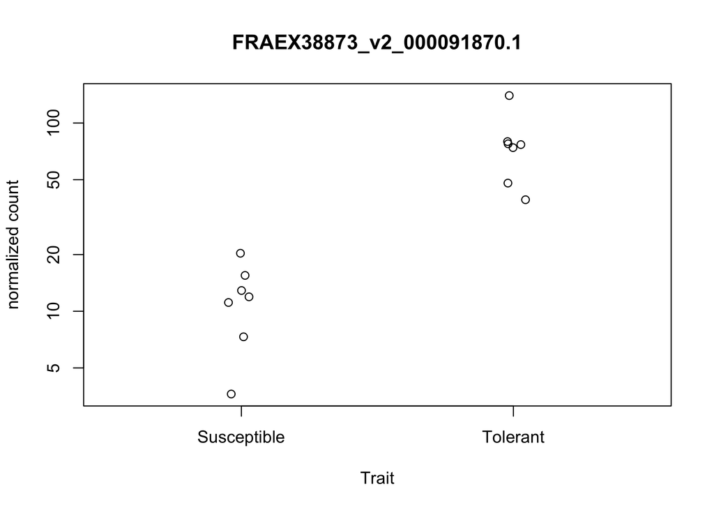

```r
# To plot the gene most differentially expressed (lowest p-value):
plotCounts(dds, gene = which.min(res_lfc$padj),
           intgroup = "chalara",
           xlab = "Trait")
```

The DESeq2 results can also be visualised through heatmaps using the function **`pheatmap()`** (Kolde 2019). To improve the appearance of these, the function **`normTransform()`** must be applied to perform a transformation of log2(n+1) to the DESeq2 results. The results can then be plotted using clustering of the genes and trees to make trends clearer to identify since they will be grouped by similarity in their expression pattern. This can help identify genes which are biological signatures associated with the particular disease. An example of this can be seen in Figure 3.1 - for the sample data used this appears to be the best way to identify the most differentially expressed genes.

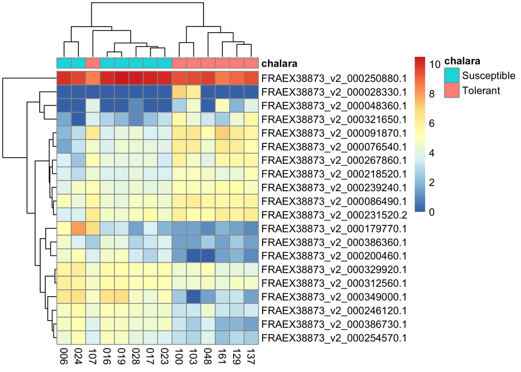

Figure 3.1: Example heatmap where the trees and genes were clustered to help pattern identification. Each row represents a gene and each column represents a single ash tree sampled. The trait of each tree is indicated by the light blue and pink squares above the heatmap. The colour of each square indicates the level of gene expression, as shown by the legend. The genes with the lowest p-values (most differentially expressed) are shown.

It may be useful to remove clustering so that the genes are shown in order of increasing p-value and the trees are shown in the same order as the data set. By viewing the results without clustering, as seen in Figure 3.2, it may be easier to see which genes are associated with certain traits.

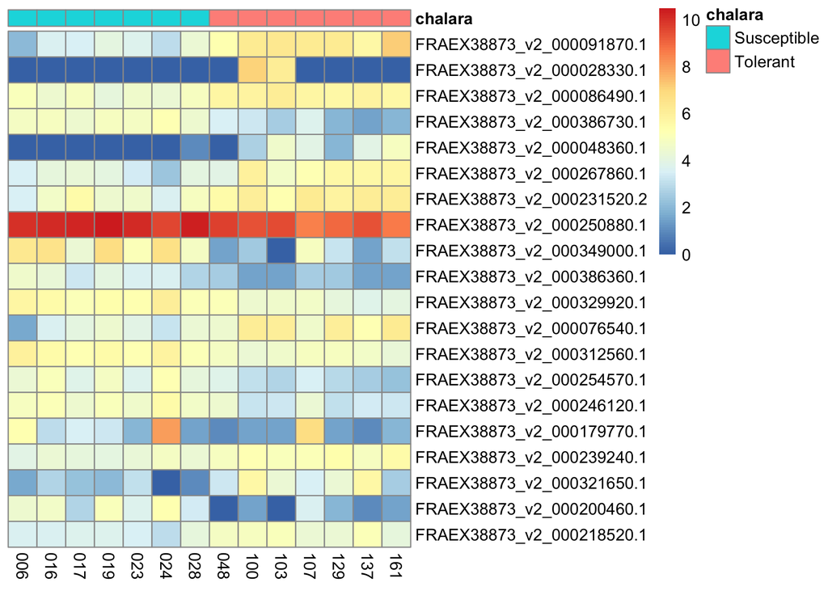

Figure 3.2: Example heatmap where the trees and genes were not clustered. Each row represents a gene and each column represents a tree sampled. Genes are in order of p-value and trees are in the same order as the data set. The trait of each tree is indicated by the light blue and pink squares above the heatmap. The colour of each square indicates the level of gene expression, as shown by the legend. The genes with the lowest p-values (most differentially expressed) are shown.

# 4 Further analysis

## 4.1 Data tidying

For further analysis, the data needs to be formatted so each column represents a gene and each row is a tree sampled. The trait of each tree sampled was also added as an extra column. It was useful to filter the data to contain only the genes identified in the DESeq2 analysis as being significantly differentially expressed since these are most likely to show clear trends. This tidied data was saved as expression_filtered.txt.

## 4.2 PCA

Principal Components Analysis (PCA) was used to investigate whether there were patterns in the sample data. It is a dimension reduction method which creates a set of components that are linear combinations of the original variables. PCA was conducted on gene expression levels scaled to unit variance so that highly expressed genes did not dominate the analysis.

In the sample data, the first principal component (PC1) captured 71% of the variation in gene expression between samples and the first six components together captured 97%. The distributions of scores on PC1 for the trees sampled show good separation between those with different disease susceptibilities. However, the groups were difficult to separate based on more than one component, as shown by the pairwise scatter plots of the first six principle components in Figure 4.1 produced using the package GGally (Schloerke et al. 2020). This suggests that since only one component was able to clearly separate the groups, the FRAEX38873_v2_000386730.1 gene (which has the greatest contribution to PC1) may have the greatest role in determining whether the tree will be susceptible or tolerant to Chalara ash dieback.

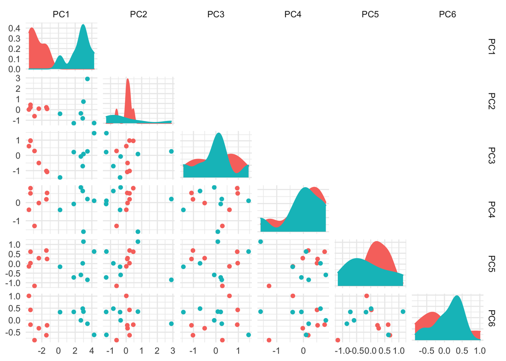

Figure 4.1: Ash tree samples represented by their first six principal components capturing 97% of the variation in gene expression levels between samples. The leading diagonal shows the distribution of scores on each component and pairwise scatter plots of principal components are shown beneath. Trees susceptible to Chalara ash dieback are coloured red and trees that are tolerant are coloured blue. As seen, only PC1 is able to clearly separate trees with different traits.

## 4.3 t-SNE

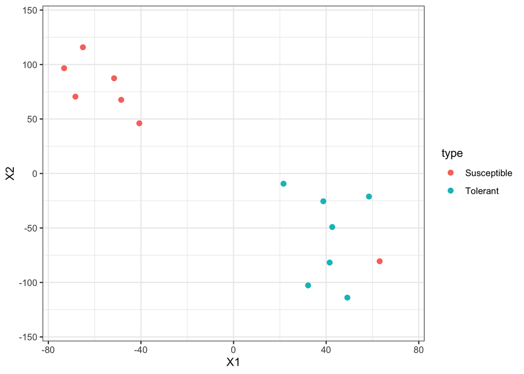

## 4.4 LDA

Linear discriminant analysis (LDA) can determine how well a tree’s susceptibility to the disease can be predicted from its gene expression levels. The data needs to be randomly split into training and test data sets using the dplyr **`slice()`** function which filters rows based on their index rather than a match to a condition. This means that 75% of the data can be used to create the model and the remaining 25% can be used to test how generalisable the model is.

Since the sample data only featured two categories of disease susceptibility (susceptible & tolerant) the LDA was only able to create one linear discriminant (LD1). The separation between trees of different traits is stronger in the LDA than in the PCA, as seen in Figure 4.3. The gene with the highest value for LD1 was FRAEX38873_v2_000329920.1 therefore, this suggests this gene has a large role in determining an ash tree’s susceptibility to the disease.

A subset of data was used to test the LDA model and the **`confusionMatrix()`** function gave an evaluation of the performance of the classification model. The accuracy of the LDA model when predicting a tree’s susceptibility to the disease based on its gene expression levels was determined to be 100%.

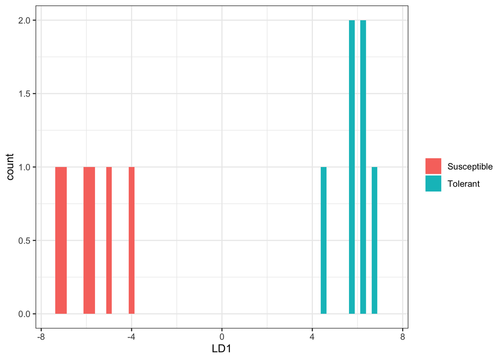

Figure 4.3: Histogram plot of first linear discriminant (LD1) scores for each ash tree sampled, with their susceptibility to Chalara ash dieback shown as indicated by the legend. There is a strong separation between trees with different traits. The gene FRAEX38873_v2_000329920.1 has the highest value in the LD1 so correlates with this dimension.

# 5 Word count

The word count for this document and the README was calculated using wordcountaddin (Marwick 2020).

This document: 1744

README: 239

**Total: 1983 words**

# References

Allaire, JJ, Yihui Xie, Jonathan McPherson, Javier Luraschi, Kevin Ushey, Aron Atkins, Hadley Wickham, Joe Cheng, Winston Chang, and Richard Iannone. 2019. *Rmarkdown: Dynamic Documents for R*. https://github.com/rstudio/rmarkdown.

Forest Research. 2020. “Ash Dieback (Hymenoscyphus Fraxineus).” https://www.forestresearch.gov.uk/tools-and-resources/pest-and-disease-resources/ash-dieback-hymenoscyphus-fraxineus/.

Kolde, Raivo. 2019. *Pheatmap: Pretty Heatmaps*. https://CRAN.R-project.org/package=pheatmap.

Marwick, Ben. 2020. *Wordcountaddin: Word Counts and Readability Statistics in R Markdown Documents*.

R Core Team. 2019. *R: A Language and Environment for Statistical Computing*. Vienna, Austria: R Foundation for Statistical Computing. https://www.R-project.org/.

Schloerke, Barret, Di Cook, Joseph Larmarange, Francois Briatte, Moritz Marbach, Edwin Thoen, Amos Elberg, and Jason Crowley. 2020. *GGally: Extension to ’Ggplot2’*. https://CRAN.R-project.org/package=GGally.

Wickham, Hadley. 2017. *Tidyverse: Easily Install and Load the ’Tidyverse’*. https://CRAN.R-project.org/package=tidyverse.

Xie, Yihui. 2016. *Bookdown: Authoring Books and Technical Documents with R Markdown*. Boca Raton, Florida: Chapman; Hall/CRC. https://github.com/rstudio/bookdown.

Zhu, A, JG Ibrahim, and MI Love. 2018. *Heavy-Tailed Prior Distributions for Sequence Count Data: Removing the Noise and Preserving Large Differences*. https://doi.org/10.1093/bioinformatics/bty895.